# Pneumonia Detection using ViT and EfficientNet with Explainability

### Vision Transformer Model Training

```python
class ViTWrapper(layers.Layer):
    def __init__(self, vit_model, **kwargs):
        super().__init__(**kwargs)
        self.vit_model = vit_model

    def call(self, inputs):
        inputs = tf.transpose(inputs, perm=[0, 3, 1, 2])
        return self.vit_model(pixel_values=inputs).last_hidden_state

base_model = TFViTModel.from_pretrained('google/vit-base-patch16-224-in21k')
for layer in base_model.layers:
    layer.trainable = False

input_layer = keras.Input(shape=(224, 224, 3))
x = ViTWrapper(base_model)(input_layer)
x = layers.GlobalAveragePooling1D()(x)
x = layers.BatchNormalization()(x)
x = layers.Dropout(0.45)(x)
x = layers.Dense(220, activation='relu')(x)
x = layers.Dropout(0.25)(x)
x = layers.Dense(60, activation='relu')(x)
output_layer = layers.Dense(1, activation='sigmoid')(x)

model = keras.Model(inputs=input_layer, outputs=output_layer)
model.compile(optimizer=Adamax(learning_rate=0.001), loss='binary_crossentropy', metrics=['accuracy'])

early_stopping = EarlyStopping(monitor='val_loss', patience=10, restore_best_weights=True)

history = model.fit(train_ds, validation_data=val_ds, epochs=50, callbacks=[early_stopping])
```

```
All PyTorch model weights were used when initializing TFViTModel.

All the weights of TFViTModel were initialized from the PyTorch model.
If your task is similar to the task the model of the checkpoint was trained on, you can already use TFViTModel for predictions without further training.
```

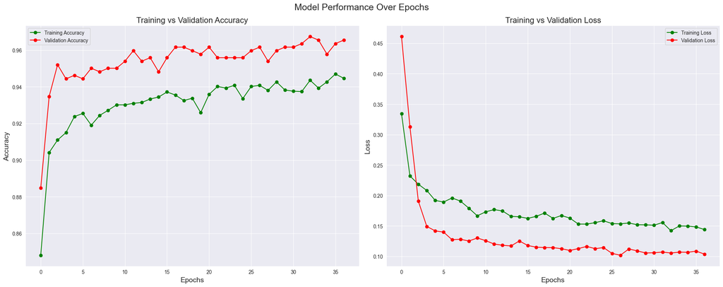

```python
# Automatically calculate the number of epochs used (in case early stopping kicks in)
epochs = range(len(history.history['accuracy']))

# Set up figure
fig, ax = plt.subplots(1, 2, figsize=(20, 8))

# Accuracy Plot
ax[0].plot(epochs, history.history['accuracy'], 'go-', label='Training Accuracy')
ax[0].plot(epochs, history.history['val_accuracy'], 'ro-', label='Validation Accuracy')
ax[0].set_title('Training vs Validation Accuracy', fontsize=16)
ax[0].set_xlabel('Epochs', fontsize=14)
ax[0].set_ylabel('Accuracy', fontsize=14)
ax[0].legend()
ax[0].grid(True)

# Loss Plot
ax[1].plot(epochs, history.history['loss'], 'g-o', label='Training Loss')
ax[1].plot(epochs, history.history['val_loss'], 'r-o', label='Validation Loss')
ax[1].set_title('Training vs Validation Loss', fontsize=16)
ax[1].set_xlabel('Epochs', fontsize=14)
ax[1].set_ylabel('Loss', fontsize=14)
ax[1].legend()
ax[1].grid(True)

plt.suptitle("Model Performance Over Epochs", fontsize=18)
plt.tight_layout()
plt.show()
```

## The two plots above illustrate the model’s learning dynamics during training

### Test-Time Augmentation

```python
def predict_with_tta(model, dataset, augment_fn, num_augments=5):
    y_true, y_preds = [], []
    for images, labels in dataset:
        aug_preds = []
        for _ in range(num_augments):
            aug_images = augment_fn(images)
            aug_preds.append(model.predict(aug_images))
        avg_preds = np.mean(aug_preds, axis=0)
        y_preds.extend((avg_preds > 0.5).astype(int).flatten())
        y_true.extend(labels.numpy())
    return np.array(y_true), np.array(y_preds)

@tf.function
def horizontal_flip(images):
    return tf.image.random_flip_left_right(images)

y_true_tta, y_pred_tta = predict_with_tta(model, test_ds, horizontal_flip)
print("TTA Classification Report:\n", classification_report(y_true_tta, y_pred_tta))
```

```
TTA Classification Report:
               precision    recall  f1-score   support

           0       0.98      0.66      0.79       234
           1       0.83      0.99      0.90       390

    accuracy                           0.87       624
   macro avg       0.91      0.83      0.85       624
weighted avg       0.89      0.87      0.86       624
```

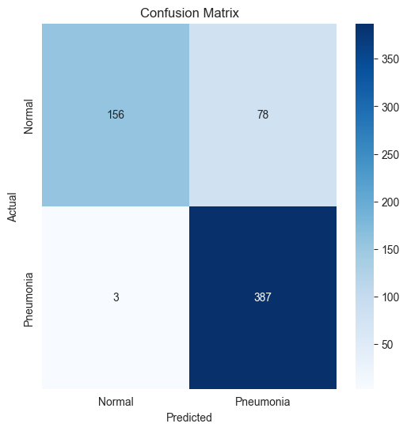

```python
y_true, y_pred = [], []
for images, labels in test_ds:
    preds = model.predict(images)
    y_true.extend(labels.numpy())
    y_pred.extend((preds > 0.5).astype(int).flatten())

# Confusion Matrix
cm = confusion_matrix(y_true, y_pred)
plt.figure(figsize=(6,6))
sns.heatmap(cm, annot=True, fmt='d', cmap='Blues', xticklabels=['Normal', 'Pneumonia'], yticklabels=['Normal', 'Pneumonia'])
plt.xlabel('Predicted'); plt.ylabel('Actual'); plt.title('Confusion Matrix')
plt.show()
```

#### Confusion Matrix Analysis

The confusion matrix provides a detailed breakdown of classification performance:

- True Positives (Pneumonia correctly predicted): 387
- True Negatives (Normal correctly predicted): 156
- False Positives (Normal misclassified as Pneumonia): 78
- False Negatives (Pneumonia misclassified as Normal): 3

##### The model demonstrates excellent sensitivity (recall) for detecting pneumonia, with only 3 missed cases out of 390.

##### However, the number of false positives (78) suggests that some normal chest X-rays are being incorrectly flagged as pneumonia.

##### While this conservative behavior helps avoid missed pneumonia cases, it may lead to unnecessary clinical interventions or anxiety.

##### To further improve, the next step should focus on increasing specificity — reducing false positives — without compromising sensitivity.

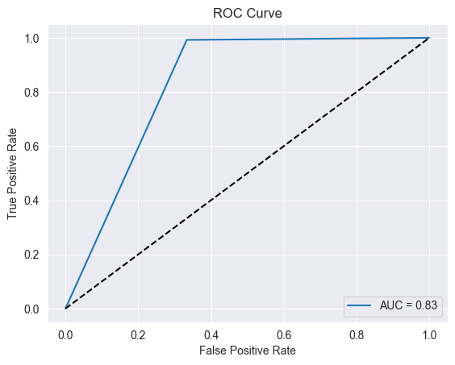

```python
# ROC Curve
fpr, tpr, _ = roc_curve(y_true, y_pred)
roc_auc = auc(fpr, tpr)
plt.plot(fpr, tpr, label=f'AUC = {roc_auc:.2f}')
plt.plot([0, 1], [0, 1], 'k--')
plt.xlabel('False Positive Rate'); plt.ylabel('True Positive Rate'); plt.title('ROC Curve')
plt.legend(loc='lower right'); plt.show()
```